# Lab2 Rmarkdown, data and visualization

# Rmarkdown document and chunks of code

Today I will show you how to open a Rmd document how to creat chunks of code and what options in chunks of code mean.

- To create an Rmarkdown document in Rstudio go to File > New File > Rmarkdown
- The Rmarkdown Cheatsheet in the Cheatsheets folder on the files tabs on Canvas walks your through the steps of creating an Rmarkdown document, write content and titles, and render or knit your document.
- To create a chunk of code you can to Ctr+alt+i in PC or Command+alt+i in Mac
- inside the `{r }` at the begging of each chunk of code you can add the knitr options for that chunk. That means you are telling R what you want with those results or how you want to present those.
- `include = FALSE` prevents code and results from appearing in the finished file. R Markdown still runs the code in the chunk, and the results can be used by other chunks.
- `echo = FALSE` prevents code, but not the results from appearing in the finished file. This is a useful way to embed figures.
- `eval = FALSE` prevents the evaluation of the code, but not the code from appearing in the finished file.
- `message = FALSE` prevents messages that are generated by code from appearing in the finished file. warning = FALSE prevents warnings that are generated by code from appearing in the finished.
- `fig.cap = "..."` adds a caption to graphical results.

Important knitr options for our class are also:

- `results = 'asis'` shows the results form your code as they are. that allows you to have html code showing nicely in your final document more on this later in the semester.
- `results='hold'` hold the results of each line of code in your chunk and shows them all together after running the chunk.

See the [R Markdown Reference Guide](https://www.rstudio.com/wp-content/uploads/2015/03/rmarkdown-reference.pdf) for a complete list of knitr chunk options.

# Create your own objects

Let’s practice a few things from your first few classes

```r
#Generate a random variable v1 of 100 observations from the normal distribution between 0 and 1
v1<-rnorm(100,0,1)
# and show its variance two ways with the formula call it sv1, with the var() function call it sigmav1
(sv1<-sum((v1-mean(v1))^2)/99)
```

```
[1] 1.049906
```

```r
(sigmav1<-var(v1))
```

```
[1] 1.049906
```

```r
#Generate another random variable v2 with greater variance and show that it calculates to greater variance.
# let's do it for the arguments 0, 4
v2<-rnorm(100,0,4)
(sigmav2<-var(v2))
```

```
[1] 14.76441
```

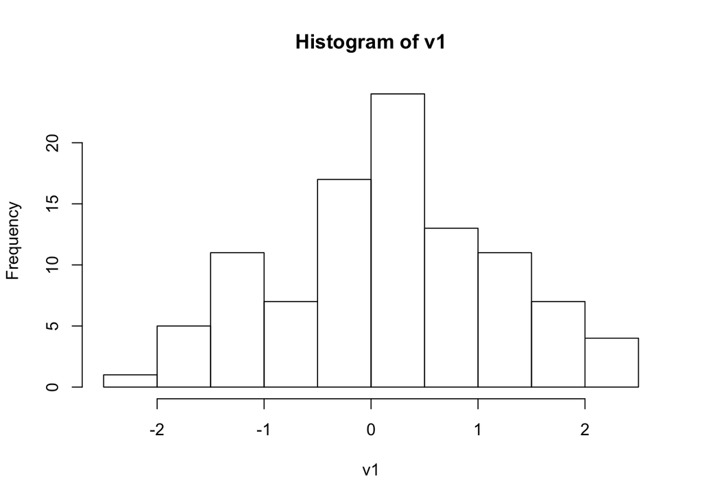

```r
#Show histograms for the two.
hist(v1)
```

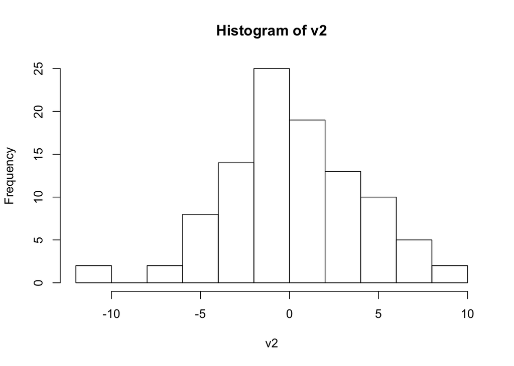

```r
hist(v2)
```

```r
#Generate a 3rd variable v3 that is a function of the first variable with additional noise. Calculate the covariance of v3 and v1.
u<-rnorm(100,0,1)
v3<-2*v1 + u
sigmav13<-cov(v1,v3)
#Generate a 4th variable v4 that has the opposite direction of covariance with v1. Show that the covariance is now negative.
v4<--2*v1 + u
(sigmav14<-cov(v1,v4))
```

```
[1] -2.11262
```

```r
#Create a dataframe with all these variables
dat<-data.frame(v1,v2,v3,v4)
```